# safe: stock assessments in Rmarkdown

Ben Williams

2023-08-23

# Goal

The goal of safe is to create a formally structured set of .Rmd files to produce a SAFE report that is reproducible. Since we often collaborate with folks who are not `R/Rmarkdown/Quarto` savvy, and we need 508 compliance this package outputs a word .docx file.

# Background

There is a lot of information out there about using markdown, R markdown, bookdown, pandoc, LaTeX, and YAML. We aren’t going to cover all of that, we are going to target generating pdf documents (maybe word and webpages if desired) using Rmarkdown/bookdown in the RStudio IDE.

**Important** “By tailoring your work to a single output format, you may improve the appearance and performance of a single output format, but at the expense of this transferability.” - Xie et al.2022

That means making a .Rmd file that produces exactly what you want in .pdf typically will not be correctly displayed in .docx or .html.

If you want other/additional options then look at [rmarkdown](https://bookdown.org/yihui/rmarkdown/) and [RStudio markdown intro](https://rmarkdown.rstudio.com/lesson-1.html) and [bookdown](https://bookdown.org/yihui/rmarkdown-cookbook/) are all quite informative.

Be sure to have this all up and running, and update your packages

R 4.1.2+  
RStudio v21.09.2+  
`install.packages("bookdown")`  
A version of LaTeX if you want tp produce any .pdf docs (recommend `tinytex`)

```r
install.packages('tinytex')
tinytex::install_tinytex()
tinytex::pdflatex('test.tex')
```

## Things you may have heard…

But may not know what they are

**Programs/packages**

- `markdown` a (very) simple markup language used for formatting text, gets converted to a specified output by `pandoc`.
- `Rmarkdown` a flavor of `markdown` (there are many)
- `Sweave` R function that allows for combining R code with `LaTeX`, pretty much usurped by `Rmarkdown` these days
- `LaTeX` (pronounced lah-tech) typesetting software, very powerful, steep learning curve. Necessary to create .pdf documents
- `knitr` *“Sweave reborn” - [K. Broman](https://kbroman.org/knitr_knutshell/pages/overview.html)“*
- `bookdown` R package for formatting multi-chapter documents in `Rmd`
- `blogdown` R package for making websites using `Rmd`
- `pagedown` R package for making paginated html documents - basically html that looks kinda .pdf like
- `pkgdown` R package for creating Rpackage documentation website
- `quarto` Separate program that effectively acts like `Rmd`, but for multiple languages (R, Python, Julia) - essential where things are going, don’t worry it renders `Rmd` files.

**Other items**

- `YAML` a heading of sorts
- `chunk` or `block` a section of code that can be compiled with a `Rmd` document starts and ends with 3 backticks `` ``` ``
- `bibtex` aka “use bibtex for your bibliography”
  - store references in a `.bib` file
  - `bibtex` & `biber` are programs that interface the `.bib` file with `LaTeX`
  - `natbib` & `biblatex` are `LaTeX` packages that format references
- `csl` citation style language - format your references
- `css` cascading style sheet - format html
- `template` Rmd pre-formatted templates, contain a `skeleton`

## Install and setup

### Workflow

Setup an R project, include sub directories for data, R scripts, figures, documents. Won’t matter so much to start, but is very important further along.

```
project
  |-- data
  |-- R
  |-- figs
  |-- tables
  |-- presentation
```

Install the `safe` R package as you would for any other github based package.

```r
# install.packages("remotes")
remotes::install_github("BenWilliams-NOAA/safe")
```

Then open a new R markdown file.

[figure not shown]

A panel will pop up, click `From Template` and then click either `safe` or `partial_safe` (I’ll add the other variants once the guidelines are settled). Name the file `safe` and give it a location that you want to have the document. Then hit `OK`.

[figure not shown]

A folder named `safe` will be placed in the location previously identified. *Note: this assumes, and works best, if your assessment is setup as an Rproject.*

[figure not shown]

In our example folder structure above it would look like this:

```
project
  |-- data
  |-- R
  |-- figs
  |-- tables
  |-- presentation
  |-- safe
```

In the case of a “full safe” there will be a number of files in the folder.

[figure not shown]

## Layout

It may seem like there is a lot going on, but it will hopefully make sense soon… There is a “parent” document with a suite of “child” documents.

- safe.Rmd - parent document
- 01 - summary.Rmd - summary section
- 01a,b,c - tables that may (or not) go in the summary
- 02 through 14 - various sections as identified in our previous stock assessment guidelines document
- _bookdown.yml helper for adjusting fig/table captions - no need to touch
- .lua files additional helper files for author blocks and figure captions - no need to touch
- safe_bibby.bib - bibliography file - we’ll get to this
- skeleton.log LaTeX log file from building the package - ignore it
- styles.css a place to adjust appearances if you are outputting to .html - ignore unless you want to fancify your .html
- template.docx - a template file to use stock assessment guildelines formats - should be up to date

The reason for the independent files is that each child document can be turned on or off when needed, additionally it facilitates group workflow via github. For example, collaborators could communicate who is responsible for each section, once they are pushed up someone else can edit, in this manner merge conflicts can be reduced, if not eliminated.

# Editing

## Title and sections

First open the `safe.Rmd` file, then change the `params:` section in the YAML at the top of the file. Here I’ve change it to how I have the GOA northern rockfish setup. The `params` section are variables that are used in the YAML and can be called via R code.

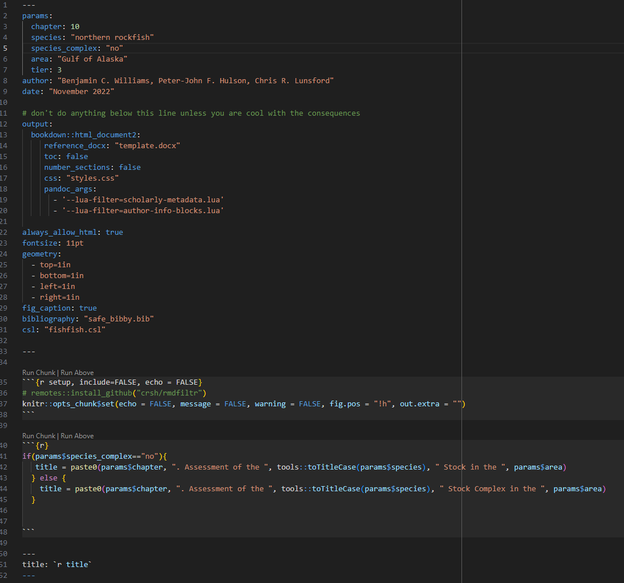

The YAML will pull everything in correctly (or should anyway!), I recommend entering the species/stock name as lower case so that it can be used later as inline R code.

There is a `load` chunk that has `global variables` in it. These variables will be available to all the child documents.

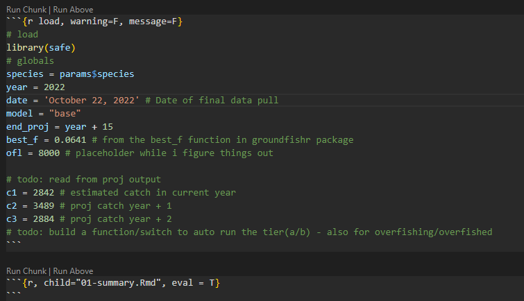

If there are any sections that you do not want to run simply change the `eval = T` to `eval = F`.

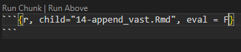

To create a document simply hit the `knit` button in Rstudio. *Note: I keep the format in .html for editing and switch to* `word_document2:` *when I’m ready to finalize, I also turn off the table and figures sections if I’m just focused on writing/editing text to speed up compile times*

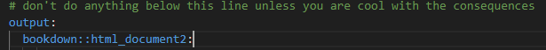

## Tables

The “main table” has been pre-formatted and provided in a function `safe::main_table()`.

Example data for different tiers to work with this function are in the `safe/data` folder. Simply replace the data file with your assessment output and it should generate the appropriate table.

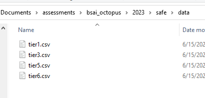

The “main table” is generated in `01a-main_table.Rmd` *Note: Tiers 2 &4 are not currently represented, also for Tiers 5&6 just enter 1 for catch data (c1, c2, c3)*.

Tables from .Rmd to .docx are a bit of a pain. If you are in a pinch, I recommend simply exporting your table data as a .csv then editing in Excel/Word.

## Figures

By far the easiest way to manage figures for a SAFE is to generate them via code, store them in a `fig` folder and call them with `knitr::include_graphics()`. *Do Not* try to generate them in the body of the document, it is much easier to re-run the figure and recompile the doc than to try to keep track of a massive document full of text and code combined.

[output not shown]

```r
knitr::include_graphics(here::here(year, pref_mod, "figs", "swath.png"))
```

[output not shown]

This figure has a label `fswath` (same as the chunk label) which can now be referenced as Figure 10-@ref(fig:fswath). If the location of the figure is moved the reference number will update to match when compiled.

## References

Viva la bibtex! We are going to need a bibliography file, it will be in a `.bib` format, and will be placed in the YAML a la `bibliography: safe_bibby.bib`

A standard `.bib` file contains items that looks something like:

```
@article{CitekeyArticle,
  author   = "P. J. Cohen",
  title    = "The independence of the continuum hypothesis",
  journal  = "Proceedings of the National Academy of Sciences",
  year     = 1963,
  volume   = "50",
  number   = "6",
  pages    = "1143--1148",
}
```

You can export your references in `bibtex` format from Zotero, Mendelay, EndNote, etc.  
Additionally, you can pull references in by going to the online journal article and downloading the bibtex file or go to Google Scholar entering the name of the article clicking on “““Cite” like so:

[figure not shown]

Then clicking on `BibTeX` on the bottom:

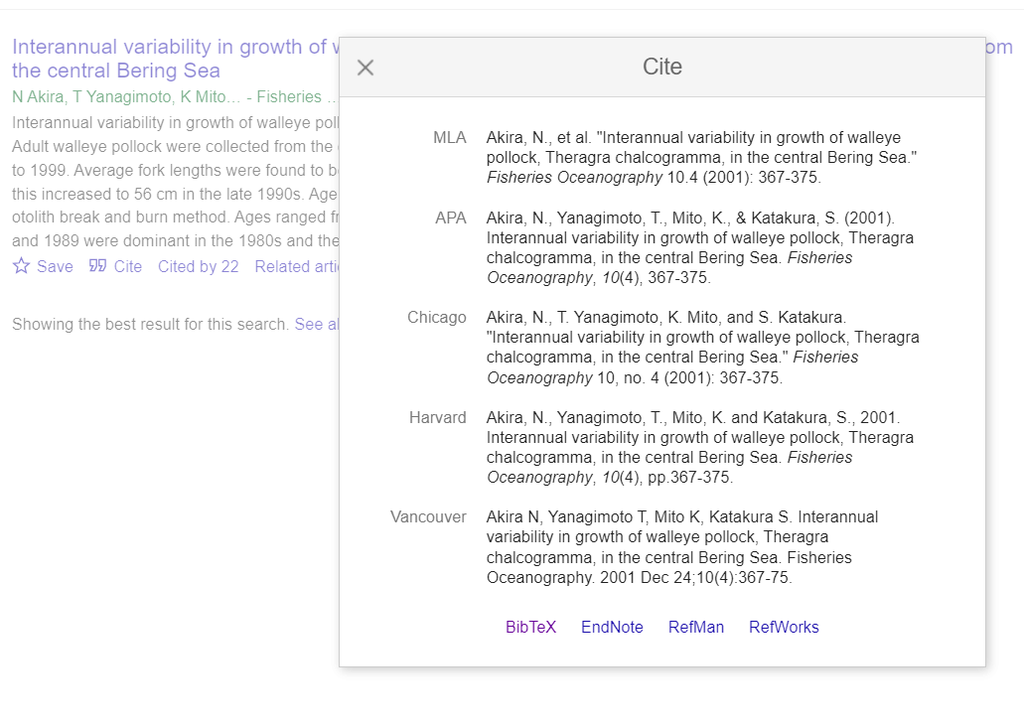

You can also pull `BibTeX` files from digital object identifiers (doi). This is available from numerous R packages e.g., `RefManageR::GetBibEntryWithDOI`.

**Always check that autoloaded references are correct (they often are not)**

My recommendation is to slightly change references so that it will work well with `bibtex` and `biblatex`, mainly this is using a single `CitekeyArticle` style and using `{}` instead of `"` throughout. Otherwise there are times when capitalization will not work correctly.

```
@article{Akira2001,
      Author = {Akira, N and Yanagimoto, T and Mito, K and Katakura, S},
      DOI = {10.1046/j.1365-2419.2001.00181.x},
      ISSN = {10546006},
      Journal = {Fisheries Oceanography},
      Number = {4},
      Pages = {367--375},
      Title = {Interannual variability in growth of walleye pollock, \emph{Theragra chalcogramma}, in the central {Bering Sea}},
      URL = {http://www.blackwell-synergy.com/doi/abs/10.1046/j.1365-2419.2001.00181.x},
      Volume = {10},
      Year = {2001}
}

@article{Ahrestani2013,
  doi = {10.1038/srep03125},
  url = {http://dx.doi.org/10.1038/srep03125},
  year = {2013},
  month = {nov},
  publisher = {Nature Publishing Group},
  volume = {3},
  author = {Farshid S. Ahrestani and Mark Hebblewhite and Eric Post},
  title = {The importance of observation versus process error in analyses of global ungulate populations},
  journal = {Scientific Reports}
}
```

Note that there is LaTeX code in the Akira2001 title `\emph` or `\textit` is used to italicize, and braces are used to capitalize `{Bering Sea}`.

To use this in a document it would look like:

```
---
title: "test"
author: "Ben Williams"
date: "4/20/2022"
output:
  bookdown::pdf_document2
bibliography: references.bib
---

Something about limited entry management [@Akira2001] and @Ahrestani2013 talks about process error.
Also, some opinions were stated [@Akira2001; @Ahrestani2013].

# References
```

This will produce an output that looks like:

```
Something about limited entry management (Akira et al. 2001) and Ahrestani et al. (2013) talks about
process error. Also, some opinions were stated (Akira et al. 2001; Ahrestani et al. (2013)).

References

Ahrestani, F.S., Hebblewhite, M., and Post, E. 2013. The importance of observation versus process er-
ror in analyses of global ungulate populations. Scientific Reports 3. Nature Publishing Group. doi:
10.1038/srep03125.
Akira, N., Yanagimoto, T., Mito, K., and Katakura, S. 2001. Interannual variability in growth of walleye
pollock, theragra chalcogramma, in the central Bering Sea. Fisheries Oceanography 10(4): 367–375. doi:
10.1046/j.1365-2419.2001.00181.x.
```

Note the square brackets around Akira and not around Ahrestani and the differing outputs. Additionally, see that the references are in alphabetical order.

There are numerous entry types for `.bib` files: article, book, booklet, conference… [see here](https://www.bibtex.com/e/entry-types/)

You can also find styles - no more changing reference formats by hand.  
[Styles](https://www.zotero.org/styles) or [build/tweak your own](https://readthedocs.org/projects/citation-style-language/downloads/pdf/master/) These are added to the YAML as well by changing the `.csl` file.

```
---
title: "test"
author: "Ben Williams"
date: "4/20/2022"
output:
  bookdown::pdf_document2
bibliography: references.bib
csl: canjfas.csl
---
```

Citations keys take the @ sign while square brackets and/or minus signs introduce variation

# Odds and ends

## R markdown structure

### YAML

Rhymes with camel: Header material that tells R markdown how to render your document.  
**Important** indentation and spacing matter!

- When you knit:
  - .Rmd -> knitr -> .md -> pandoc -> out
  - output can be .docx, .html, .pdf, and others
- YAML: ‘Yet Another Markup Language’ morphed to ‘YAML Ain’t Markup Language’

### (Very) brief primer on LaTeX

A TeX distribution can be thought of like base R, generally useful but doesn’t provide loads of functionality. Much like R, LaTeX requires packages that provide a range of options and functionality. There are many (4,000+). Packages can be added to preamble (YAML) of your document in a couple of ways:

1. using a separate file

```
    output:
      # rmdformats::downcute:
      bookdown::pdf_document2:
        includes:
          in_header: "preamble.tex"
```

2. adding statements directly to the YAML

```
    header-includes:
        \usepackage{fvextra}
        \DefineVerbatimEnvironment{Highlighting}{Verbatim}{
          breaksymbolleft={},
          showspaces = false,
          showtabs = false,
          breaklines,
          commandchars=\\\{\}
        }
        \pagenumbering{gobble}
        \linenumbers
```

or 3. using the `extra_dependencies` statement

```
    output:
      bookdown::pdf_document2:
        extra_dependencies:
          caption: ["labelfont={bf}"]
          hyperref: ["unicode=true", "breaklinks=true"]
          lmodern: null
```

[CTAN](https://www.ctan.org/) houses LaTeX packages. A couple of good packages to know about are:

- `multicol` & `multirow` which allow for more columns or rows, handy for complex tables
- `geometry` allows for specification of document size and margins
- `hyperref` allows for easier inclusion of hyperlinks
- `fvextra` automatic line breaks etc.
- `float` keeps figs/tables where you want them - you will want this

A fair number of these packages are rolled into `bookdown` but it doesn’t hurt to know how to look for their options or other packages.

Some more resources  
[Learn LaTeX in 30 minutes](https://www.overleaf.com/learn/latex/Learn_LaTeX_in_30_minutes) hahaha…  
[tex.stackexchange](https://tex.stackexchange.com/)

# Syntax

R markdown follows the syntax in Pandoc’s markdown - have a look at the [cheat sheet](https://www.rstudio.com/wp-content/uploads/2015/02/rmarkdown-cheatsheet.pdf)  
I’ll only cover some of the more esoteric aspects of the syntax.

## Lines

Line spacing of text become quite valuable particularly for larger documents.

Sentences *on the same line will be read in line and produce the same output*.

```
I have one space following. So continues as a single line in a paragraph.
I have two spaces following.  So continues as a single line in a paragraph.
I have three spaces following.   So continues as a single line in a paragraph.
```

Results in:  
I have one space following. So continues as a single line in a paragraph.  
I have two spaces following. So continues as a single line in a paragraph.  
I have three spaces following. So continues as a single line in a paragraph.

```
I have one space following with a return._
So continues as a paragraph._
Pretty much how we normally write things._

I have two spaces following with a return.__
So continues as a paragraph.__
Which can get a bit odd as each is a new line, but the same paragraph (almost list form).__

I have three spaces following with a return.___
So continues as a paragraph.___
Produces the same as two spaces.___
```

Results in:  
I have one space following with a return. So continues as a paragraph. Pretty much how we normally write things.

I have two spaces following with a return.  
So continues as a paragraph.  
Which can get a bit odd as each is a new line, but the same paragraph (almost list form).

I have three spaces following with a return.  
So continues as a paragraph.  
Produces the same as two spaces.

```
I have one space following with a return._
So continues as a paragraph.

A space between lines starts a new paragraph...
```

A space between lines starts a new paragraph…

*Note: Multiple blank lines between paragraphs reduce to one.*

When writing follow each sentence with one space and a new line, because tracking down issues and editing text (finding the correct location or id location on `GitHub`) is much easier later on if your document looks like:

```
Pollock have been sampled in the western Gulf of Alaska (Figure \@ref{fig:map}; Table \@ref(tab:sample)) during spring acoustic surveys since 1983 [@NMFS2013].
Macroscopic estimates of female maturity have been determined using a 5-stage [@Stahl2008a] or 8-stage key [@Williams2007], which were condensed to immature/mature with pre-spawning and later stages considered mature.
Fish were measured for fork length to the nearest cm and weighed in grams; ages were determined by the AFSC Age and Growth Program [@Matta2012].
Ovary samples of mature pollock were collected opportunistically from AFSC trawl surveys and stored in 10\% buffered formalin solution.
Each sample had associated location and date of capture information as well as individual weight (g), fork length (cm) and age information.
The spatial extent of these data is dependent upon the sampling location of the NMFS survey trawls and incorporates regional variability.
Samples were typically collected from winter pre-spawning cruises, allowing us to examine annual variability.
```

instead of this

[output not shown]

Behind the scenes this will look like:

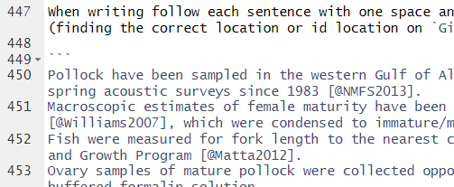

Where every sentence starts on it’s own line, instead of this:

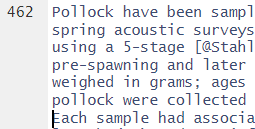

Where the entire paragraph is treated as a single sentence.

Spaces on lines that start with a vertical line `|` are kept

```
| one-space
|     five-space
|        eight-space
```

Text with the syntax `<!--your comments -->` is omitted from output

`[visit my website](https://www.noaa.gov/)` becomes [visit my website](https://www.noaa.gov/)  
`[www.noaa.gov](https://www.noaa.gov/)` becomes [www.noaa.gov](https://www.noaa.gov/)  
or just wright the website https://www.noaa.gov/ - which will be converted when the doc is compiled.

## Nested lists

Can be generated using `*`, `+`, or `-` or can be numbered.

```
1. play
   - ski
   - camp
2. sleep
3. work
   - computer
      + programs
```

1. play
   - ski
   - camp
2. sleep
3. work
   - computer
     - programs

## The maths

Inline equations go between a pair of single dollar signs `$` — with no space between the signs and the equation itself

Einstein figured out $E=mc^2$, but you are smarter. `$E=mc^2$`

Block equations go in between a pair of double dollar signs.
Einstein figured out
$$E=mc^2,$$
but you are smarter. `$$E=mc^2,$$`

Numbered equations are easy (in .pdf), just need to bring in some LaTeX.

`\begin{equation}`  
`E=mc^2,`  
`\end{equation}`

Einstein figured out
$$\begin{equation}
E=mc^2,
\end{equation}$$
but you are smarter.

This works fine for .pdf but doesn’t number equations in .docx or .html - support for this isn’t great, but there are a couple of workarounds. Namely, adding a label using (#eq:) - see [here](https://bookdown.org/yihui/bookdown/markdown-extensions-by-bookdown.html#equations) for more info.

```
\begin{equation}
  E=mc^2
  (\#eq:eq2)
\end{equation}
```

# Recommendations

1. keep figures and tables separate
2. use `flextable` to generate tables
   - bring tables in as .csv files then manipulate (or edit in Excel and append to Word doc if the table is too complicated)
3. compartmentalize everything

# Todo

- Example of production workflow
- github tips/tricks
- table/fig/eq referencing
- complex math
- figure sizes

Probably lot’s of things I can’t think of at the moment…